# Quick EDA for Numerical Datasets

Valery Lynn

## Overview

The quickeda package is designed to take in a dataframe with mixed data types and produce an initial numerical exploratory data analysis (EDA). There are 7 functions that will produce individual sections of an EDA, and one function that will run all of them at once for quick analysis. Functions requiring numerical data types will automatically select the numerical columns from a dataframe, no initial slicing is necessary.

## Functions

The functions are as follows:

1. data_describe(df): This function prints out the dataframe shape and the column names.
2. data_types(df): This function prints out the data types for the variables in a dataframe.
3. data_stats(df): This function prints out descriptive statistics for the variables in a dataframe.
4. make_df(df): This function creates a numeric dataframe.
5. dens_plots(df): This function prints kernel density plots for all numeric variables.
6. qq_plots(df): This function prints QQ-plots for all numeric variables
7. correlations(df): This function produces a correlation pairs table of all numerical variables in a dataframe.
8. quick_eda(df): This function calls all of the above functions to produce an initial EDA.

## Example Data

The “overdose” data is a cleaned data set of county level data of drug overdose mortality rates and social, economic, and demographic indicators. Raw data used to assemble this data were acquired from “The County Health Rankings” dataset, a collaboration between the Robert Wood Johnson Foundation and the University of Wisconsin Population Health Institute.This database was built predominantly from the following: The Behavioral Risk Factor Surveillance System (BRFSS), the National Center for Health Statistics, and the CDC WONDER mortality data.

The database for the rankings is available for downloading as an Excel spreadsheet at: http://www.countyhealthrankings.org/explore-health-rankings/rankings-data-documentation

For a full account of how data for each variable was attained see: http://www.countyhealthrankings.org/sites/default/files/resources/2017_Measures_DataSources Years.pdf

## How to install the R package

The following command will download the quickeda package from Github:

devtools::install_github(“ValeryLynn/Quick_EDA”)

## Demonstration of Functions

```r
library(quickeda)
#Get data
overdose <- read.csv(file="overdose.csv", header=TRUE, sep=",")
df_od <- overdose[,1:10]
head(df_od)
```

```
#>   drugmort fips   state   county aamort chmort infmort physdistr mentdistr
#> 1       10 1001 Alabama  Autauga    468     55       7        12        13
#> 2       17 1003 Alabama  Baldwin    361     48       6        12        12
#> 3       15 1007 Alabama     Bibb    521    105      12        13        13
#> 4       21 1009 Alabama   Blount    445     44       6        13        13
#> 5       13 1015 Alabama  Calhoun    550     70       8        14        14
#> 6       14 1019 Alabama Cherokee    523     61       8        13        14
#>   diabetic
#> 1       13
#> 2       10
#> 3       15
#> 4       14
#> 5       15
#> 6       13
```

## Methods

### Initial look at the data: data_describe(df)

```r
data_describe(df_od)
```

```
#> Dataframe shape (rows X columns)
#>  1623 10
#>
#> Column names:
#>  [1] "drugmort"  "fips"      "state"     "county"    "aamort"
#>  [6] "chmort"    "infmort"   "physdistr" "mentdistr" "diabetic"
```

### A check of the data types: data_types(overdose)

```r
data_types(df_od)
```

```
#>
#> Data types:
#>  drugmort      fips     state    county    aamort    chmort   infmort
#> "integer" "integer"  "factor"  "factor" "numeric" "numeric" "numeric"
#> physdistr mentdistr  diabetic
#> "integer" "integer" "integer"
```

### Descriptive statistics

```r
data_stats(df_od)
```

```
#>
#> Summary statistics:
#>     drugmort          fips                  state             county
#>  Min.   : 3.00   Min.   : 1001   Kentucky      :  86   Washington:  18
#>  1st Qu.:12.00   1st Qu.:18134   Texas         :  81   Franklin  :  15
#>  Median :16.00   Median :32007   Ohio          :  79   Jackson   :  15
#>  Mean   :18.16   Mean   :30856   North Carolina:  77   Jefferson :  15
#>  3rd Qu.:22.00   3rd Qu.:43067   Tennessee     :  73   Lincoln   :  13
#>  Max.   :93.00   Max.   :56041   Georgia       :  71   Montgomery:  13
#>                                  (Other)       :1156   (Other)   :1534
#>      aamort          chmort          infmort         physdistr
#>  Min.   :151.0   Min.   : 18.00   Min.   : 3.000   Min.   : 7.00
#>  1st Qu.:321.5   1st Qu.: 44.00   1st Qu.: 6.000   1st Qu.:10.00
#>  Median :381.0   Median : 54.00   Median : 7.000   Median :12.00
#>  Mean   :392.4   Mean   : 56.27   Mean   : 6.778   Mean   :11.86
#>  3rd Qu.:456.0   3rd Qu.: 66.00   3rd Qu.: 8.000   3rd Qu.:13.00
#>  Max.   :901.0   Max.   :140.00   Max.   :16.000   Max.   :21.00
#>
#>    mentdistr        diabetic
#>  Min.   : 8.00   Min.   : 3.00
#>  1st Qu.:11.00   1st Qu.: 9.00
#>  Median :12.00   Median :11.00
#>  Mean   :11.88   Mean   :11.14
#>  3rd Qu.:13.00   3rd Qu.:13.00
#>  Max.   :19.00   Max.   :19.00
#>
```

### Select only numeric columns

```r
df = make_df(df_od)
head(df)
```

```
#>   drugmort fips aamort chmort infmort physdistr mentdistr diabetic
#> 1       10 1001    468     55       7        12        13       13
#> 2       17 1003    361     48       6        12        12       10
#> 3       15 1007    521    105      12        13        13       15
#> 4       21 1009    445     44       6        13        13       14
#> 5       13 1015    550     70       8        14        14       15
#> 6       14 1019    523     61       8        13        14       13
```

### Kernel density plots

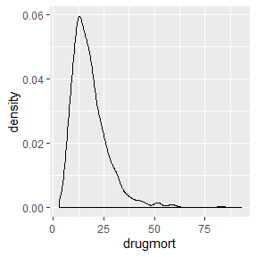

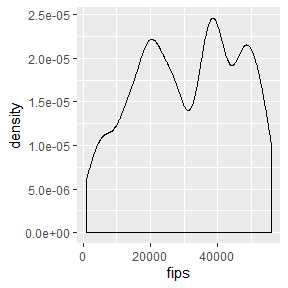

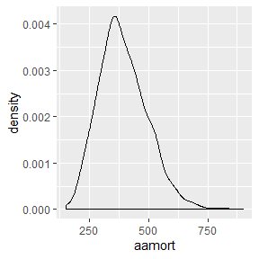

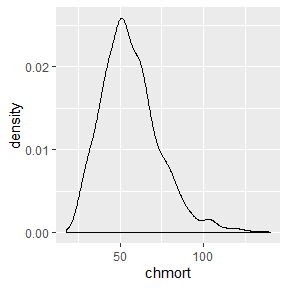

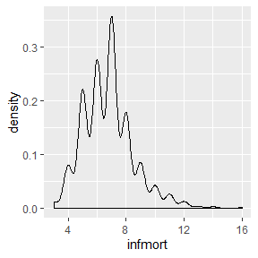

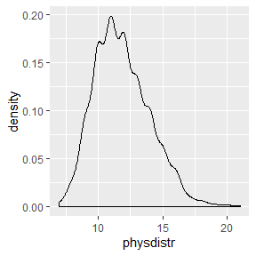

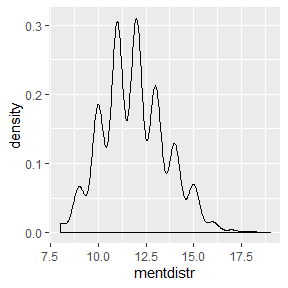

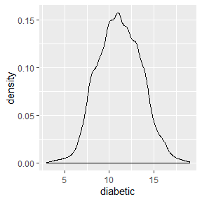

```r
dens_plots(df_od)
```

### QQ-Plots

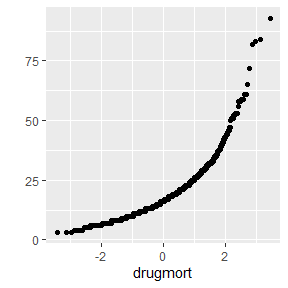

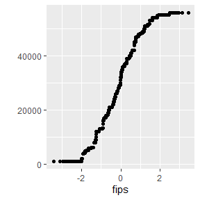

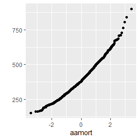

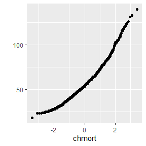

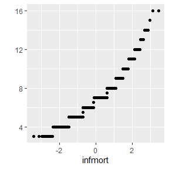

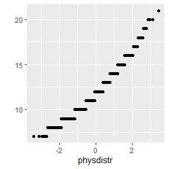

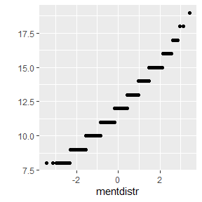

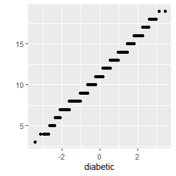

```r
qq_plots(df_od)
```

### Correlation pairs table

```r
correlations(df_od)
```

```
#>
#> Correlations:
#>         Var1      Var2         Freq
#> 1   drugmort  drugmort  1.000000000
#> 2       fips  drugmort  0.061605853
#> 3     aamort  drugmort  0.506716472
#> 4     chmort  drugmort  0.218851603
#> 5    infmort  drugmort  0.160132915
#> 6  physdistr  drugmort  0.365965176
#> 7  mentdistr  drugmort  0.371140486
#> 8   diabetic  drugmort  0.324957856
#> 9   drugmort      fips  0.061605853
#> 10      fips      fips  1.000000000
#> 11    aamort      fips -0.010473631
#> 12    chmort      fips -0.055282820
```

[output cut: 52 more lines]

### Output of entire EDA

```r
quick_eda(df_od)
```

```
#> Dataframe shape (rows X columns)
#>  1623 10
#>
#> Column names:
#>  [1] "drugmort"  "fips"      "state"     "county"    "aamort"
#>  [6] "chmort"    "infmort"   "physdistr" "mentdistr" "diabetic"
#>
#> Data types:
#>  drugmort      fips     state    county    aamort    chmort   infmort
#> "integer" "integer"  "factor"  "factor" "numeric" "numeric" "numeric"
#> physdistr mentdistr  diabetic
#> "integer" "integer" "integer"
#>
#> Summary statistics:
#>     drugmort          fips                  state             county
#>  Min.   : 3.00   Min.   : 1001   Kentucky      :  86   Washington:  18
#>  1st Qu.:12.00   1st Qu.:18134   Texas         :  81   Franklin  :  15
#>  Median :16.00   Median :32007   Ohio          :  79   Jackson   :  15
#>  Mean   :18.16   Mean   :30856   North Carolina:  77   Jefferson :  15
#>  3rd Qu.:22.00   3rd Qu.:43067   Tennessee     :  73   Lincoln   :  13
#>  Max.   :93.00   Max.   :56041   Georgia       :  71   Montgomery:  13
#>                                  (Other)       :1156   (Other)   :1534
#>      aamort          chmort          infmort         physdistr
#>  Min.   :151.0   Min.   : 18.00   Min.   : 3.000   Min.   : 7.00
#>  1st Qu.:321.5   1st Qu.: 44.00   1st Qu.: 6.000   1st Qu.:10.00
#>  Median :381.0   Median : 54.00   Median : 7.000   Median :12.00
#>  Mean   :392.4   Mean   : 56.27   Mean   : 6.778   Mean   :11.86
#>  3rd Qu.:456.0   3rd Qu.: 66.00   3rd Qu.: 8.000   3rd Qu.:13.00
#>  Max.   :901.0   Max.   :140.00   Max.   :16.000   Max.   :21.00
#>
#>    mentdistr        diabetic
#>  Min.   : 8.00   Min.   : 3.00
#>  1st Qu.:11.00   1st Qu.: 9.00
#>  Median :12.00   Median :11.00
#>  Mean   :11.88   Mean   :11.14
#>  3rd Qu.:13.00   3rd Qu.:13.00
#>  Max.   :19.00   Max.   :19.00
#>
```

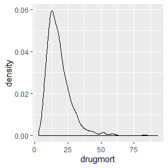

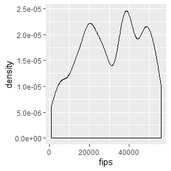

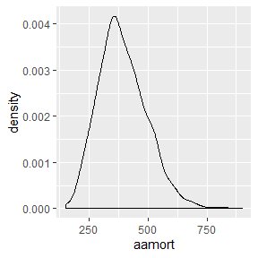

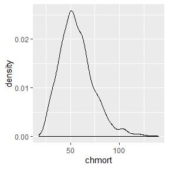

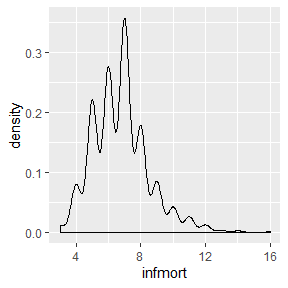

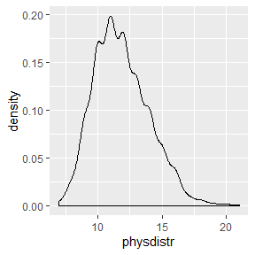

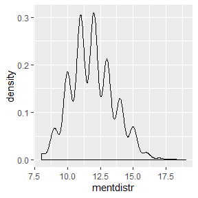

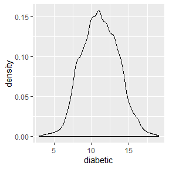

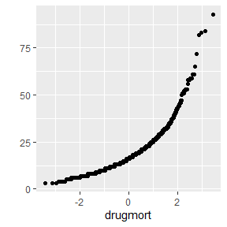

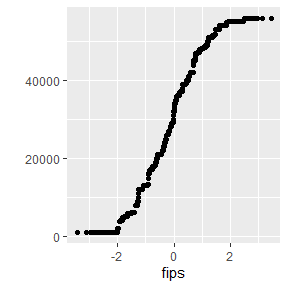

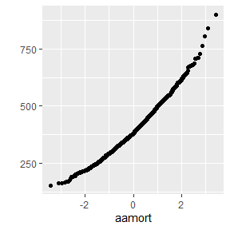

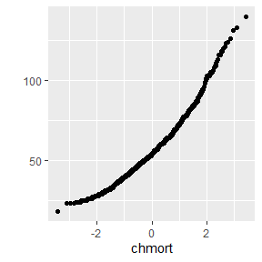

[4 more figures not shown]

```
#>
#> Correlations:
#>         Var1      Var2         Freq
#> 1   drugmort  drugmort  1.000000000
#> 2       fips  drugmort  0.061605853
#> 3     aamort  drugmort  0.506716472
#> 4     chmort  drugmort  0.218851603
#> 5    infmort  drugmort  0.160132915
#> 6  physdistr  drugmort  0.365965176
#> 7  mentdistr  drugmort  0.371140486
#> 8   diabetic  drugmort  0.324957856
#> 9   drugmort      fips  0.061605853
#> 10      fips      fips  1.000000000
#> 11    aamort      fips -0.010473631
#> 12    chmort      fips -0.055282820
```

[output cut: 52 more lines]